# Nonlinear Models

### Polynomial logistic regression

Now we fit a logistic regression model to a binary response variable constructed from `wage`. We code the big earners (`>250K`) as 1 and low earners (`<250K`) as 0.

```r
fit=glm(I(wage>250)~poly(age,3),data=Wage,family=binomial)
# can do logistic regression on the fly with glm
# I() wrapper function with conditional on wage evaluates to T/F function
# which is then coded as a 0,1 binary variable for glm
summary(fit)
```

```
##
## Call:
## glm(formula = I(wage > 250) ~ poly(age, 3), family = binomial,
##     data = Wage)
##
## Deviance Residuals:
##     Min       1Q   Median       3Q      Max
## -0.2808  -0.2736  -0.2487  -0.1758   3.2868
##
## Coefficients:
##               Estimate Std. Error z value Pr(>|z|)
## (Intercept)    -3.8486     0.1597 -24.100  < 2e-16 ***
## poly(age, 3)1  37.8846    11.4818   3.300 0.000968 ***
## poly(age, 3)2 -29.5129    10.5626  -2.794 0.005205 **
## poly(age, 3)3   9.7966     8.9990   1.089 0.276317
## ---
## Signif. codes:  0 '***' 0.001 '**' 0.01 '*' 0.05 '.' 0.1 ' ' 1
##
## (Dispersion parameter for binomial family taken to be 1)
##
##     Null deviance: 730.53  on 2999  degrees of freedom
## Residual deviance: 707.92  on 2996  degrees of freedom
## AIC: 715.92
##
## Number of Fisher Scoring iterations: 8
```

```r
# because glm involves weights on observations, the
# polynomial fit is no longer orthogonal and we get
# different values for the coefficients
# with glm would have to separately test polynomials
# of different degrees (e.g., 1 then 2 then 3) and
# compare directly to see what degree polynomial is best
preds=predict(fit,list(age=age.grid),se=T)
se.bands=preds$fit + cbind(fit=0,lower=-2*preds$se,upper=2*preds$se)
# different syntax for SE bands here: want predictions
# from fit to be a center of bands, so start with that
# vector as definition for bands, then define cbind
# centered at 0 with upper/lower limit which gives 3xn
# matrix; then fit vector is simply added to all three
# columns and replicated n times
se.bands[1:5,]
```

```
##         fit      lower     upper
## 1 -7.664756 -10.759826 -4.569686
## 2 -7.324776 -10.106699 -4.542852
## 3 -7.001732  -9.492821 -4.510643
## 4 -6.695229  -8.917158 -4.473300
## 5 -6.404868  -8.378691 -4.431045
```

We have done the computations on the logit scale. `predict` fits the linear predictor, which is on the logit scale. We’re usually more iterested in the predictions on the probability scale. To transform we need to apply inverse logit mapping:
$$p=\frac{e^\eta}{1+e^\eta}.$$
We can do this simultaneously for all three columns of `se.bands`:

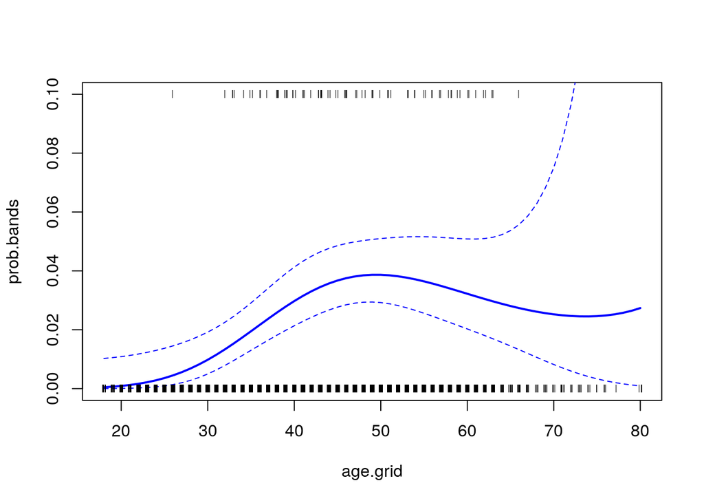

```r
prob.bands=exp(se.bands)/(1+exp(se.bands))
matplot(age.grid,prob.bands,col='blue',lwd=c(2,1,1),lty=c(1,2,2),type='l',ylim=c(0,0.1))
points(jitter(age),I(wage>250)/10,pch="|",cex=0.5)
```

```r
# jitter function adds a bit of uniform random noise
# to each vector in age
# (scale for 0,1 wage binary is limited to fit on plot)
```